# Venture Tutorial: Part 1

### 2. Ripl to MRipl

The state of a Venture RIPL includes a single value for each random variable in the model. But the Bayesian posterior would assign probabilities to every possible value of a variable. This motivates using a *set* of RIPLs instead of a single one. With a set of RIPLs, each having the same model but different random seeds, we have quick access to an approximate distribution on values.

The set of RIPLs is called an MRipl (multi-RIPL). The syntax for interacting with an MRipl is identical to that for a RIPL. As with RIPLs, we have a choice of Venture backend. We also need to specify the number of RIPLs in the MRipl, which we set to '80' for this example.

```python
from venture.venturemagics.ip_parallel import MRipl
v=MRipl(80)
```

```
MRipl has 80 ripls and 40 ripl(s) per engine
```

```python
%%venture v
[clear]
```

```
Total transitions set to 0
```

```python
%%venture v 12
[assume is_tricky (flip 0.1)]
[assume coin_weight (if is_tricky (uniform_continuous 0 1) 0.5)]
```

```
Ripl 0 of 80:  [False, 0.5]
Ripl 1 of 80:  [False, 0.5]
Ripl 2 of 80:  [False, 0.5]
Ripl 3 of 80:  [False, 0.5]
Ripl 4 of 80:  [False, 0.5]
Ripl 5 of 80:  [False, 0.5]
Ripl 6 of 80:  [False, 0.5]
Ripl 7 of 80:  [True, 0.22733907494693995]
Ripl 8 of 80:  [False, 0.5]
Ripl 9 of 80:  [True, 0.3644610261544585]
Ripl 10 of 80:  [False, 0.5]
Ripl 11 of 80:  [False, 0.5]
...
```

The cell above defines the 'Tricky Coin' model above for each of the 80 RIPLs. The RIPLs are independent samples from the same prior distribution: their values for `is_tricky` and `coin_weight` will vary. We control how many RIPL outputs are displayed with the second argument to `%%venture`.

In the following cells we generate data from the model. A single `sample` procedure will now generate a coin flip for each of the 80 RIPLs and so it's convenient to avoid displaying all of them.

```python
%%venture v 5
[sample (flip coin_weight)]
[sample (flip coin_weight)]
[sample (flip coin_weight)]
[sample (flip coin_weight)]
[sample (flip coin_weight)]
[sample (flip coin_weight)]
```

```
Ripl 0 of 80:  [True, True, False, True, True, False]
Ripl 1 of 80:  [False, False, False, True, True, True]
Ripl 2 of 80:  [True, True, False, False, False, True]
Ripl 3 of 80:  [True, False, False, True, True, False]
Ripl 4 of 80:  [False, False, True, False, False, False]
...
```

```python
# Using the Python object-method syntax, an MRipl's output is in a Python list.
# We slice the list to avoid showing all 80 coin flips.
print v.sample('(flip coin_weight)')[:20]
```

```
[False, False, True, False, False, False, True, False, False, True, False, False, False, True, True, False, True, False, False, True]
```

```python
print 'is_tricky: ', v.sample('is_tricky')[:8]
print ' 1st flip: ', v.sample('(flip coin_weight)')[:8]
print ' 2nd flip: ', v.sample('(flip coin_weight)')[:8]
print ' 3rd flip: ', v.sample('(flip coin_weight)')[:8]
```

```
is_tricky:  [False, False, False, False, False, False, False, True]
 1st flip:  [False, True, True, False, False, True, True, False]
 2nd flip:  [False, True, True, True, False, True, False, False]
 3rd flip:  [False, True, True, False, True, False, False, False]
```

Since the MRipl provides 80 independent samples from our prior, we can use it to approximate properties of our prior.

First we estimate the expectation of the coin being True (actual value is 0.5 due to symmetry).

Below we use the `snapshot` MRipl method to plot a histogram and Gaussian kernel density estimator (GKDE) of `coin_weight` values. (The KDE is misleading here because the distribution has such a sharp peak at 0.5).

```python
print 'Proportion True/Total flips: ', np.mean( v.sample('(flip coin_weight)') )
```

```
Proportion True/Total flips:  0.5625
```

```
Before inference: P(is_tricky)=  0.125
```

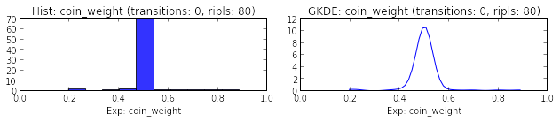

```python
print 'Before inference: P(is_tricky)= ', np.mean(v.sample('is_tricky'))
prior_samples = v.snapshot( exp_list=('coin_weight',), plot=True, xlims_ylims=((0,1),) )
```

### 3. Conditioning on Data

So far we have simulated from a simple probabilistic model (Tricky Coin). This could easily be done in a standard, non-probabilistic language (e.g. Python or C++). The advantage of Venture comes in conditioning the model on data and doing approximate Bayesian inference.

We condition using the directive `observe`, which has the form: `python [observe <expression> <value>]` For our Tricky Coin model, we condition on a series of flips of the coin.

```python
%%venture v
[observe (flip coin_weight) true]
[observe (flip coin_weight) true]
[observe (flip coin_weight) true]
```

Having observed three 'Heads' outcomes, we expect the probability that the coin is tricky to increase. The `observe` directive does not itself alter this probability (exercise: test this for yourself). To alter the prior probability of `is_tricky` we use the `infer` directive to run approximate Bayesian inference on the conditioned model.

The default version of `infer` has an integer argument for the number of Markov chain transitions. Here we run 50 transitions and then plot the new MRipl distribution over `coin_weight`.

```
After observing three Heads:  P(is_tricky) =  0.2
```

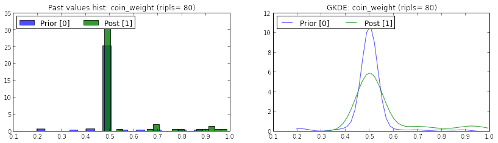

```python
v.infer(50)

print 'After observing three Heads:  P(is_tricky) = ', np.mean(v.sample('is_tricky'))

posterior_3heads = v.snapshot( ('coin_weight',) )
out = v.compare_snapshots( (prior_samples, posterior_3heads) )
```

After three 'Heads' the estimated probability of a tricky coin has increased slightly. From the plots, we see that the distribution on `coin_weight` is less peaked on '0.5' and that there is more probability mass in the right tail (and less in the left).

We now add two more observations of 'Heads' outcomes.

```python
%%venture v
[observe (flip coin_weight) true]
[observe (flip coin_weight) true]
```

```
After observing five Heads:  P(is_tricky) =  0.3625
```

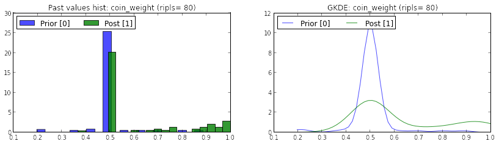

```python
v.infer(50)

print 'After observing five Heads:  P(is_tricky) = ', np.mean(v.sample('is_tricky'))
posterior_5heads = v.snapshot( ('coin_weight',) )
out = v.compare_snapshots( (prior_samples, posterior_5heads) )
```

After this inference we can use `sample` again to generate coin flips. This data will reflect our new distribution on the value of `coin_weight`.

```python
%%venture v 8
[sample (flip coin_weight)]
[sample (flip coin_weight)]
[sample (flip coin_weight)]
[sample (flip coin_weight)]
```

```
Ripl 0 of 80:  [True, True, True, True]
Ripl 1 of 80:  [True, True, True, True]
Ripl 2 of 80:  [True, True, False, True]
Ripl 3 of 80:  [True, False, True, True]
Ripl 4 of 80:  [True, True, False, True]
Ripl 5 of 80:  [True, True, True, True]
Ripl 6 of 80:  [True, True, True, True]
Ripl 7 of 80:  [False, True, False, True]
...
```

Having observed 5 'Heads' in a row, what happens if we now observe 5 'Tails'?

```python
%%venture v
[observe (flip coin_weight) false]
[observe (flip coin_weight) false]
[observe (flip coin_weight) false]
[observe (flip coin_weight) false]
[observe (flip coin_weight) false]
```

```
After observing five Heads and five Tails:  P(is_tricky) =  0.05
```

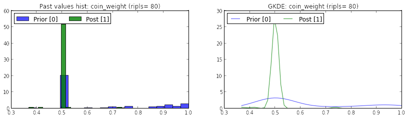

```python
v.infer(50)

print 'After observing five Heads and five Tails:  P(is_tricky) = ', np.mean(v.sample('is_tricky'))

posterior_5heads_5tails = v.snapshot( ('coin_weight',) )
out = v.compare_snapshots( (posterior_5heads, posterior_5heads_5tails) )
```

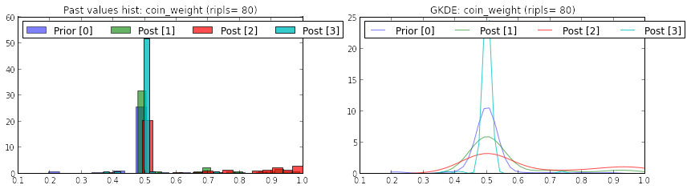

```python
all_updates = v.compare_snapshots((prior_samples,
                                  posterior_3heads,
                                  posterior_5heads,
                                  posterior_5heads_5tails) )
```

### Summary of Tricky Coin Example

In the above example, we used `observe` directives and `infer` directives incrementally. For instance we observed 3 'Heads' and did some inference, and then made more observations and did more inference. We can also add all `observe` directives at once and then do inference on all of them.

The next cell recapitulates all the modeling and inference above:

```python
from venture.venturemagics.ip_parallel import *
v=MRipl(80)
v.assume('is_tricky', '(flip 0.1)')
v.assume('coin_weight', '(if is_tricky (uniform_continuous 0 1) 0.5)')

coin_flips = (True,True,True,True,True,False,False,False,False,False)
for coin_flip in coin_flips:
    v.observe('(flip coin_weight)',coin_flip)

v.infer(200)
print 'After observing five Heads and five Tails:  P(is_tricky) = ', np.mean(v.sample('is_tricky'))
```

```
MRipl has 80 ripls and 40 ripl(s) per engine
After observing five Heads and five Tails:  P(is_tricky) =  0.0625
```

## Tricky Coin Variations

It is simple to define variations on the Tricky Coin model above. This time, we raise the prior probability of the coin being tricky. We also change the prior on `coin_weight` given that the coin is tricky.

```python
from venture.venturemagics.ip_parallel import *
v=MRipl(80)
```

```
MRipl has 80 ripls and 40 ripl(s) per engine
```

```python
%%venture v
[assume is_tricky (flip 0.5)]
[assume coin_weight (if is_tricky (beta .3 .3) 0.5)]
```

```
Ripl 0 of 80:  [False, 0.5]
Ripl 1 of 80:  [True, 0.99]
Ripl 2 of 80:  [True, 0.11865401613345974]
Ripl 3 of 80:  [False, 0.5]
Ripl 4 of 80:  [False, 0.5]
...
```

```python
%%venture v 8
[sample (flip coin_weight)]
[sample (flip coin_weight)]
[sample (flip coin_weight)]
[sample (flip coin_weight)]
```

```
Ripl 0 of 80:  [True, False, False, False]
Ripl 1 of 80:  [True, True, True, True]
Ripl 2 of 80:  [False, False, False, False]
Ripl 3 of 80:  [True, False, False, False]
Ripl 4 of 80:  [False, False, False, False]
Ripl 5 of 80:  [False, False, False, False]
Ripl 6 of 80:  [True, True, True, True]
Ripl 7 of 80:  [False, False, False, False]
...
```

We can visualize the impact of these changes to the generative model by comparing snapshots of the prior for the old and new models.

```
MRipl has 80 ripls and 40 ripl(s) per engine
MRipl has 80 ripls and 40 ripl(s) per engine
```

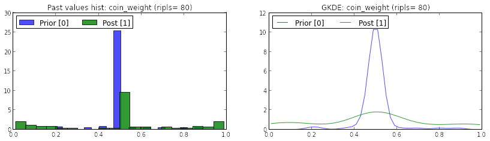

```python
v_old_prior = MRipl(80)
v_old_prior.assume('is_tricky', '(flip 0.1)')
v_old_prior.assume('coin_weight', '(if is_tricky (uniform_continuous 0 1) 0.5)')

v_new_prior = MRipl(80)
v_new_prior.assume('is_tricky', '(flip 0.5)')
v_new_prior.assume('coin_weight', '(if is_tricky (beta .3 .3) 0.5)')

old_prior = v_old_prior.snapshot('coin_weight')
new_prior = v_new_prior.snapshot('coin_weight')

out = v_new_prior.compare_snapshots((old_prior,new_prior))
```

We now condition the new prior on 3 'Heads'. This has a big impact on the distribution on `coin_weight`.

```
After observing three Heads P(is_tricky)=  0.5375
```

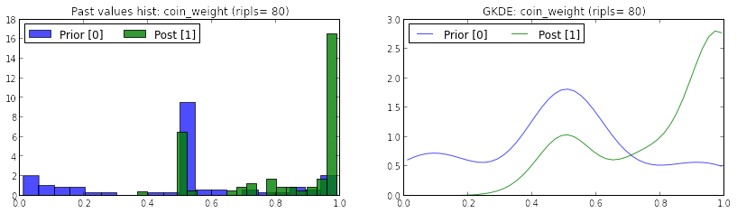

```python
for _ in range(3):
    v_new_prior.observe('(flip coin_weight)',True)

v_new_prior.infer(80)

print 'After observing three Heads P(is_tricky)= ', np.mean(v.sample('is_tricky'))
new_posterior_3heads = v_new_prior.snapshot('coin_weight')

out = v_new_prior.compare_snapshots( (new_prior,new_posterior_3heads));
```

### Switching coins over time

```python
v=MRipl(30)
```

```python
%%venture v
[clear]
```

```python
%%venture v
[assume tricky_coin_weight (uniform_continuous 0 1)]
[assume pick_tricky (mem ( (lambda (t) (if (= t 0) (flip)
                                 (if (pick_tricky (- t 1))
                                  (flip .85) (flip .3) ) ) ) )) ]
[assume flip_coin (lambda (t) (if (pick_tricky t) (flip tricky_coin_weight) (flip 0.5) ) ) ]
```

```
Ripl 0 of 30:  [0.999741748906672, 'unknown', 'unknown']
Ripl 1 of 30:  [0.4170219984371215, 'unknown', 'unknown']
Ripl 2 of 30:  [0.43599490262567997, 'unknown', 'unknown']
Ripl 3 of 30:  [0.5507979043759406, 'unknown', 'unknown']
Ripl 4 of 30:  [0.9670298383571208, 'unknown', 'unknown']
...
```

```python
%%venture v
[sample (quote WEIGHT)]
[sample tricky_coin_weight]
[sample (quote FLIPS)]
[sample (flip_coin 0) ]
[sample (flip_coin 1) ]
[sample (flip_coin 2) ]
[sample (flip_coin 3) ]
[sample (flip_coin 4) ]
[sample (flip_coin 5) ]
[sample (flip_coin 6) ]
[sample (flip_coin 7) ]
[sample (flip_coin 8) ]
[sample (flip_coin 9) ]
[sample (flip_coin 10) ]
[sample (flip_coin 11) ]
[sample (flip_coin 12) ]
[sample (flip_coin 13) ]
[sample (flip_coin 14) ]
[sample (flip_coin 15) ]
```

[output not shown]

```python
%%venture v
[observe (flip_coin 0) true ]
[observe (flip_coin 1) true ]
[observe (flip_coin 2) true ]
[observe (flip_coin 3) true ]
[observe (flip_coin 4) true ]
```

```
After observing five Heads, P(next flip is Heads)=  0.633333333333
After observing five Heads, P( tricky was picked first )=  0.366666666667
```

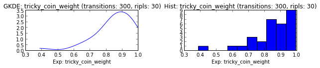

```python
v.infer(300)
print 'After observing five Heads, P(next flip is Heads)= ', np.mean(v.sample('(flip_coin 5)'))
print 'After observing five Heads, P( tricky was picked first )= ', np.mean(v.sample('(pick_tricky 0)'))
posterior1_samples=v.snapshot(exp_list='tricky_coin_weight',plot=True)
```